# Dari Rumusan ke Budaya Akademik — Sosialisasi VMTS S2 Statistika Terapan FMIPA Unpad

[figure not shown]

**S2 Statistika Terapan FMIPA Unpad** Sosialisasi VMTS kepada Dosen dan Stakeholder

Dokumentasi

Berita & Dokumentasi Penguatan Tata Kelola Akademik

# Dari Rumusan ke Budaya Akademik: Sosialisasi VMTS kepada Dosen dan Stakeholder

Program Studi S2 Statistika Terapan FMIPA Universitas Padjadjaran menempatkan sosialisasi visi, misi, tujuan, dan strategi (VMTS) sebagai proses yang berkelanjutan. Selain melalui forum khusus, substansi VMTS terus hadir dalam rapat departemen, diskusi kurikulum dan riset, penguatan jejaring, promosi program pascasarjana, serta pertemuan dengan mitra dan stakeholder.

**Forum utama** 5 Juli 2023 **Lokasi** Ruang Rapat Departemen Statistika FMIPA Unpad **Peserta** Sebagian besar dosen Statistika FMIPA Unpad **Periode VMTS** 2023–2028

01

## Sosialisasi sebagai Proses Internaliasi, Bukan Sekadar Membaca Rumusan

Sosialisasi VMTS S2 Statistika Terapan FMIPA Unpad dilaksanakan melalui beberapa agenda rapat dan forum akademik. Salah satu forum penting berlangsung pada **5 Juli 2023** di **Ruang Rapat Departemen Statistika FMIPA Unpad**, dengan kehadiran sebagian besar dosen Statistika. Forum tersebut menjadi ruang untuk membahas dokumen penyusunan VMTS periode 2023–2028 sekaligus menyamakan pemahaman mengenai arah pengembangan program studi.

Pembahasan tidak berhenti pada pilihan kata dalam dokumen. Yang lebih penting adalah bagaimana gagasan besar program studi diterjemahkan ke dalam kurikulum, mutu pembelajaran, agenda penelitian, publikasi ilmiah, pengembangan jejaring, peningkatan daya saing lulusan, serta budaya profesional dan berintegritas. Dengan pendekatan ini, VMTS menjadi rujukan bersama ketika dosen mengambil keputusan akademik—mulai dari pengembangan mata kuliah, pembimbingan mahasiswa, kerja sama riset, hingga penguatan reputasi program studi.

**Prinsip komunikasi VMTS:** bahasa yang digunakan dalam setiap forum dapat berbeda dan tidak selalu menyebut “visi”, “misi”, “tujuan”, atau “strategi” secara harfiah. Namun substansinya tetap konsisten: keunggulan pendidikan dan riset, rekognisi internasional, dampak kepada masyarakat, kolaborasi, publikasi, kualitas lulusan, serta integritas akademik.

Forum Khusus**Rapat & pembahasan dokumen VMTS**

Tanggal Utama**5 Juli 2023**

Pola Sosialisasi**Formal + kontekstual + berulang**

Jangkauan**Dosen, pimpinan fakultas, calon mahasiswa, mitra & stakeholder**

02

## Forum Dosen Departemen Statistika: Menyamakan Arah dan Bahasa Akademik

Pada forum internal, dosen mendiskusikan dokumen penyusunan VMTS dan keterkaitannya dengan perkembangan pendidikan statistika di tingkat magister. Diskusi diarahkan untuk memastikan bahwa rumusan yang disusun tidak berdiri sendiri, tetapi memiliki konsekuensi operasional yang jelas terhadap desain kurikulum, pendekatan OBE, penguatan penelitian, kerja sama, dan target luaran akademik.

Proses ini penting karena dosen merupakan aktor utama yang menerjemahkan VMTS ke dalam pengalaman belajar mahasiswa. Keselarasan pemahaman di tingkat dosen membantu memastikan bahwa pesan yang diterima mahasiswa tetap konsisten meskipun disampaikan melalui mata kuliah, bimbingan, seminar, diskusi riset, atau kegiatan pengembangan program yang berbeda.

**Hasil yang diharapkan:** VMTS menjadi “bahasa kerja” bersama dalam pengembangan program, bukan dokumen yang hanya muncul pada saat evaluasi atau akreditasi.

1

**Rumusan**  
Menegaskan arah pendidikan, riset, dan dampak program studi.

2

**Translasi**  
Menghubungkan VMTS dengan kurikulum, OBE, penelitian, dan layanan akademik.

3

**Implementasi**  
Membawa nilai VMTS ke perkuliahan, bimbingan, publikasi, dan kerja sama.

4

**Penguatan**  
Mengulang pesan yang sama melalui berbagai forum dan bahasa yang relevan dengan konteks.

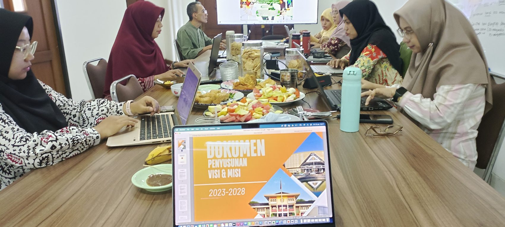

Dokumentasi pembahasan dokumen penyusunan visi dan misi periode 2023–2028 dalam forum dosen.

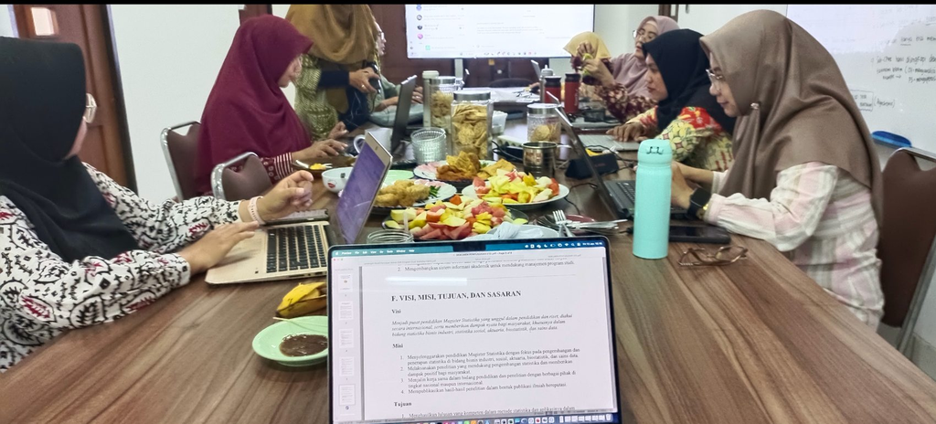

Dokumen VMTS menjadi bahan kerja untuk menyamakan substansi, arah, dan implementasi program studi.

03

## Dosen yang Terlibat dalam Rangkaian Sosialisasi dan Penguatan VMTS

25

**dosen tercantum dalam rangkaian kegiatan**

Forum dan rangkaian sosialisasi melibatkan sebagian besar dosen Statistika FMIPA Unpad. Kehadiran lintas bidang keahlian memperkuat proses penyelarasan VMTS dengan pembelajaran, penelitian, pengabdian, dan jejaring.

1. 01Prof. Yuyun Hidayat, Drs., MS., Ph.D.
2. 02Gatot Riwi Setyanto, Drs., M.Si
3. 03Dr. Titi Purwandari, Dra., MS.
4. 04Dr. Irlandia Ginanjar, M.Si
5. 05Dr. I Gede Nyoman Mindra Jaya, S.Si., M.Si
6. 06Dr. Gumgum Darmawan, S.Si., M.Si
7. 07Dr. Sri Winarni, S.Si., M.Si
8. 08Budhi Handoko, M.Si., Ph.D
9. 09Dr. Bertho Tantular, S.Si., M.Si
10. 10Achmad Zanbar Soleh, S.Si., M.Si
11. 11Resa Septiani Pontoh, S.Si., M.A.B., M.Stat.Sci.
12. 12Dr. Defi Yusti Faidah, S.Si., M.Si
13. 13Yudhie Andriyana, M.Sc., Ph.D.
14. 14Dr. Yusep Suparman, S.Si., M.Sc.
15. 15Dr. Lienda Noviyanti, M.Si
16. 16Dr. Anindya Apriliyanti Pravitasari, M.Si
17. 17Dr. Triyani Hendrawati, S.Si., M.Si.
18. 18Yeny Krista Franty, S.Si., M.Si
19. 19Dr. Restu Arisanti, S.Si., M.Si
20. 20Hasna Afifah Rusyda, S.Si., M.Stat.
21. 21Fajar Indrayatna, S.Si., M.Si.
22. 22Sinta Septi Pangastuti, S.Si., M.Stat.
23. 23Espreilla Harin Widhastika, S.Stat., M.Aktr.
24. 24Nita Cahyani, S.Si., M.Stat
25. 25Adri Arisena, S.Si., M.Stat

04

## Substansi VMTS yang Disosialisasikan

### Visi Program Studi

**“Menjadi pusat pendidikan Magister Statistika yang unggul dalam pendidikan dan riset, diakui secara internasional, serta memberikan dampak nyata bagi masyarakat, khususnya dalam bidang statistika bisnis dan industri, statistika sosial, aktuaria, biostatistika, dan sains data.”**

### Misi

1. Menyelenggarakan pendidikan dan pembelajaran Magister Statistika dengan fokus pada pengembangan dan penerapan statistika di bidang bisnis industri, sosial, aktuaria, biostatistika, dan sains data.
2. Melaksanakan penelitian yang mendukung pengembangan statistika dan memberikan dampak positif bagi masyarakat.
3. Menjalin kerja sama dalam bidang pendidikan dan penelitian dengan berbagai pihak di tingkat nasional maupun internasional.
4. Mempublikasikan hasil-hasil penelitian dalam bentuk publikasi ilmiah bereputasi.

### Tujuan

1. Mengembangkan statistika dan mengaplikasikannya melalui riset berkualitas tinggi untuk memecahkan masalah dunia nyata.
2. Memecahkan permasalahan statistika melalui pendekatan interdisipliner atau multidisipliner.
3. Mengelola riset secara efektif serta membangun kerja sama berkelanjutan dengan industri, pemerintah, dan lembaga penelitian.
4. Mengomunikasikan ide secara jelas, bekerja profesional, serta memiliki etika dan tanggung jawab tinggi.

### Strategi Pencapaian

1. Peningkatan kualitas lulusan, kurikulum, dan mutu program studi.
2. Pengembangan kurikulum berbasis riset, fasilitas penelitian, jejaring nasional–internasional, dan reputasi.
3. Peningkatan kapasitas dan kolaborasi riset dengan industri, pemerintah, dan lembaga penelitian.
4. Penguatan keterampilan menulis/presentasi ilmiah, etika, integritas akademik, dan akses literatur.

[figure not shown]

Media visual sosialisasi VMTS kepada dosen Departemen Statistika FMIPA Unpad; salah satu kegiatan utama dilaksanakan pada 5 Juli 2023.

### Dari Dokumen ke Praktik

Media visual membantu merangkum struktur VMTS, tetapi forum dosen memberikan lapisan yang lebih penting: interpretasi bersama. Dosen membahas bagaimana rumusan tersebut diterapkan dalam keputusan yang konkret.

- **Pendidikan:** kurikulum, OBE, mutu pembelajaran, dan capaian lulusan.
- **Riset:** relevansi tema, kualitas metodologi, publikasi, dan dampak.
- **Jejaring:** kerja sama dengan universitas, industri, pemerintah, dan lembaga riset.
- **Reputasi:** internasionalisasi, branding akademik, dan penguatan daya saing.
- **Budaya akademik:** integritas, etika, profesionalisme, serta komunikasi ilmiah.

05

## Sosialisasi Meluas: dari Internal Departemen ke Promosi Pascasarjana

### Universitas Islam Bandung · 28 Mei 2025

Sosialisasi arah pengembangan program tidak hanya dilakukan di lingkungan Departemen Statistika. Pada **28 Mei 2025**, kegiatan promosi program pascasarjana di lingkungan FMIPA Unpad dilakukan bersama **Wakil Dekan I FMIPA Unpad** ke **Universitas Islam Bandung**.

Dalam konteks promosi ini, VMTS dikomunikasikan melalui narasi tentang keunggulan program, kekuatan riset, peluang pengembangan kompetensi, jejaring akademik, serta kontribusi lulusan. Dengan demikian, calon mahasiswa dan mitra memperoleh gambaran bukan hanya tentang “apa programnya”, tetapi juga “ke mana program ini diarahkan”.

### Komunikasi yang adaptif terhadap audiens

Kepada audiens eksternal, substansi VMTS disampaikan dengan bahasa yang lebih komunikatif: kualitas pembelajaran, tema riset unggulan, peluang kolaborasi, rekognisi, dan dampak. Pilihan bahasa ini membuat pesan lebih relevan tanpa kehilangan substansi strategis yang menjadi dasar pengembangan program.

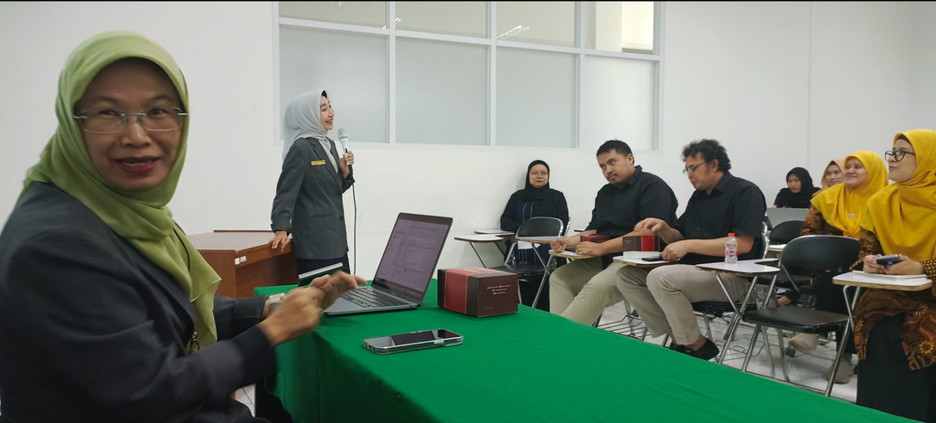

Dokumentasi sosialisasi/promosi program pascasarjana FMIPA Unpad di Universitas Islam Bandung, 28 Mei 2025.

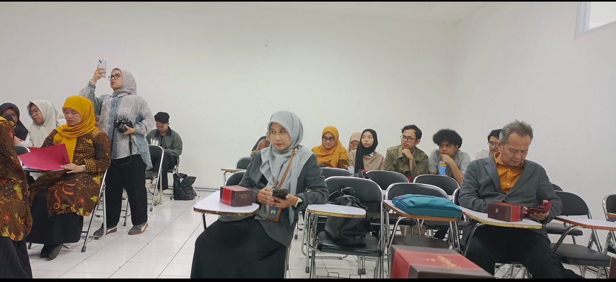

Forum promosi menjadi ruang untuk menyampaikan arah akademik, kekuatan program, dan peluang studi lanjut.

06

## Stakeholder dan Mitra: VMTS Hadir dalam Diskusi Riset, Jejaring, dan Kolaborasi

Kunjungan akademik dan pertemuan dengan stakeholder—termasuk rekan dari **Universitas Negeri Makassar** dan **Institut Teknologi Sepuluh Nopember (ITS)**—juga menjadi bagian penting dari penguatan dan sosialisasi arah program studi.

Pertemuan tersebut tidak selalu diberi label “sosialisasi visi dan misi”. Dalam banyak kesempatan, pembicaraan justru berlangsung melalui topik yang lebih substantif: pengembangan riset, strategi World Class University (WCU), peluang kolaborasi, pertukaran pengalaman akademik, penguatan publikasi, dan pengembangan jejaring. Namun secara esensial, diskusi tersebut merupakan bentuk konkret dari komunikasi VMTS karena menyampaikan arah yang sama: pendidikan dan riset berkualitas, kolaborasi yang luas, rekognisi, serta dampak yang lebih kuat.

**Makna strategis:** stakeholder tidak harus menghafal kalimat visi dan misi. Yang lebih penting, mereka memahami identitas program, prioritas pengembangan, bidang kolaborasi yang dituju, serta nilai yang ditawarkan oleh S2 Statistika Terapan FMIPA Unpad.

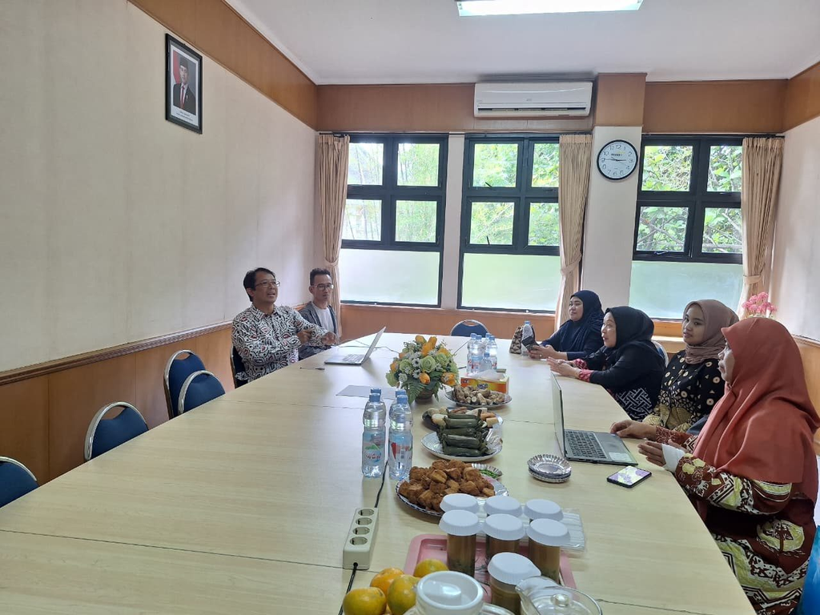

Pertemuan akademik sebagai ruang memperkenalkan arah program dan peluang kolaborasi.

[figure not shown]

Diskusi strategi penguatan WCU memperluas konteks VMTS ke reputasi dan jejaring institusional.

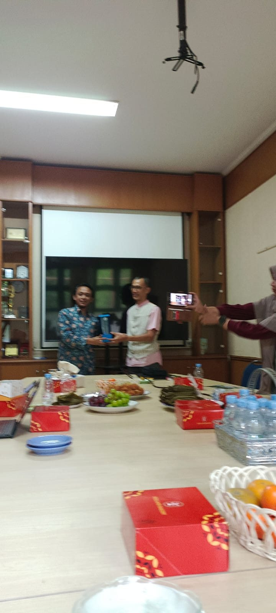

Kebersamaan dengan mitra memperkuat jejaring yang menjadi bagian dari strategi program.

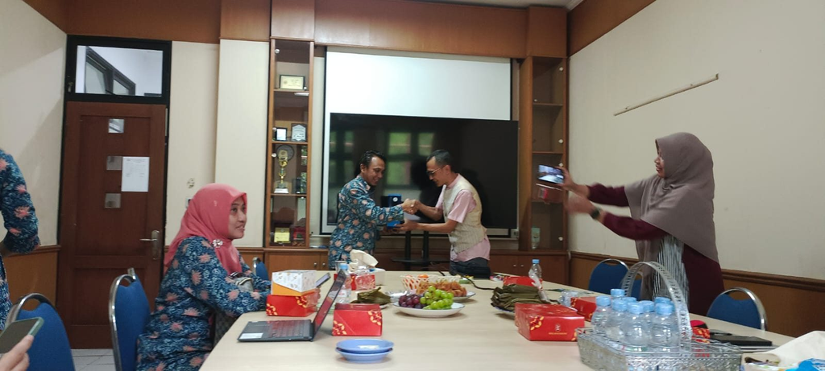

Pertemuan mitra menjadi media komunikasi nilai riset, kolaborasi, dan dampak.

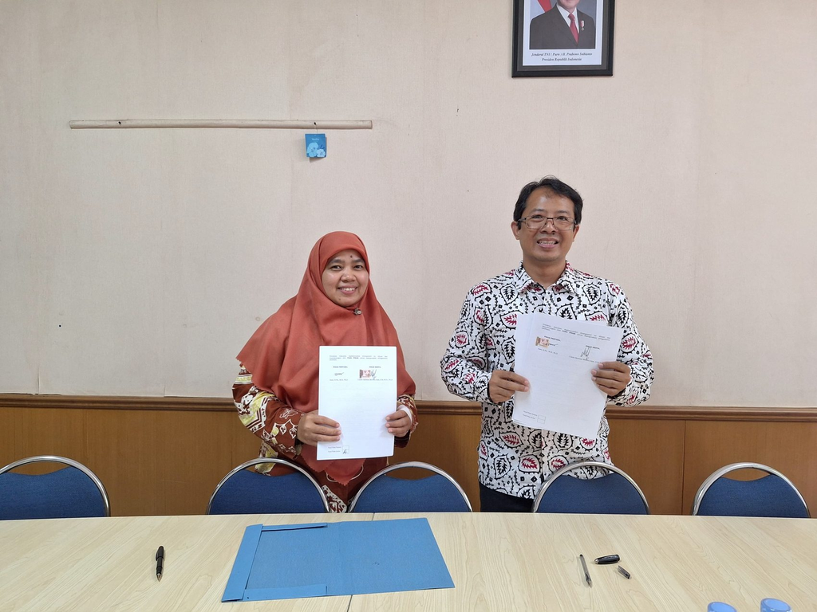

Dokumentasi penguatan hubungan akademik dan kerja sama dengan stakeholder.

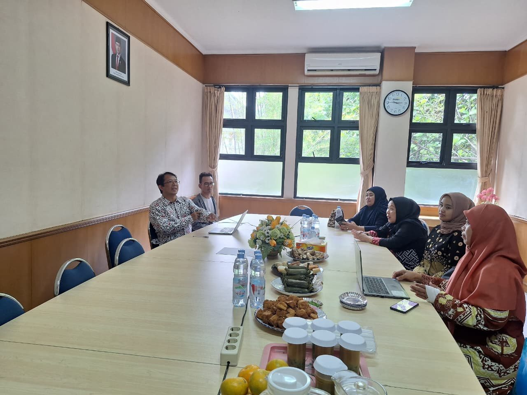

Diskusi langsung memberi ruang untuk menjelaskan fokus, kapasitas, dan agenda pengembangan program.

07

## Model Sosialisasi Berkelanjutan

Rangkaian kegiatan di atas menunjukkan bahwa sosialisasi VMTS berlangsung melalui sebuah ekosistem komunikasi. Ada forum yang secara eksplisit membahas dokumen, ada forum promosi yang menekankan keunggulan program, dan ada pula diskusi stakeholder yang fokus pada riset atau kolaborasi. Ketiganya terhubung oleh substansi yang sama.

**Konsisten dalam substansi**Pesan inti tentang mutu, riset, dampak, jejaring, dan profesionalisme tetap sama.

**Adaptif dalam bahasa**Cara penyampaian disesuaikan dengan dosen, mahasiswa, calon mahasiswa, pimpinan, atau mitra.

**Berulang dalam forum**VMTS diperkuat melalui rapat, perkuliahan, riset, promosi, kunjungan, dan kerja sama.

**Terlihat dalam tindakan**Keberhasilan sosialisasi tercermin pada kurikulum, penelitian, publikasi, jejaring, dan layanan akademik.

**Kesimpulan:** sosialisasi VMTS S2 Statistika Terapan FMIPA Unpad tidak diperlakukan sebagai kegiatan satu kali. Ia merupakan proses internalisasi dan komunikasi strategis yang terus hadir dalam kegiatan akademik dan kemitraan. Karena itu, sosialisasi dapat berlangsung dengan ungkapan verbal yang berbeda-beda, tetapi tetap membawa filosofi dan arah yang sama.

**Dokumentasi Program Studi**  
S2 Statistika Terapan  
Fakultas Matematika dan Ilmu Pengetahuan Alam  
Universitas Padjadjaran

Jatinangor, Agustus 2026

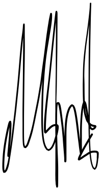

I Gede Nyoman Mindra Jaya Kaprodi S2 Statistika Terapan FMIPA UNPAD